# Test+a+Perceptual+Phenomenon+zh

### 统计学：检验心理学现象

在下方单元格中回答问题并执行相关代码，你可以 参考项目指导 并在正式提交前查看 [项目要求](https://review.udacity.com/#!/rubrics/305/view)。提交时请将 Jupyter notebook 导出成 HTML 或者 PDF 进行提交（File -> Download As）。

背景信息

在一个Stroop （斯特鲁普）任务中，参与者得到了一列文字，每个文字都用一种油墨颜色展示。参与者的任务是将文字的打印颜色大声说出来。这项任务有两个条件：一致文字条件，和不一致文字条件。在一致文字条件中，显示的文字是与它们的打印颜色匹配的颜色词，如“红色”、“蓝色”。在不一致文字条件中，显示的文字是与它们的打印颜色不匹配的颜色词，如“紫色”、“橙色”。在每个情况中，我们将计量说出同等大小的列表中的墨色名称的时间。每位参与者必须全部完成并记录每种条件下使用的时间。

调查问题

作为一般说明，请确保记录你在创建项目时使用或参考的任何资源。作为项目提交的一部分，你将需要报告信息来源。

(1) 我们的自变量是什么？因变量是什么？

自变量：congruent / incongruent 条件  
因变量：参与者使用的时间

(2) 此任务的适当假设集是什么？你需要以文字和数学符号方式对假设集中的零假设和对立假设加以说明，并对数学符号进行定义。你想执行什么类型的统计检验？为你的选择提供正当理由（比如，为何该实验满足你所选统计检验的前置条件）。

令$\mu_C$为一致文字条件下的总体均值，$\mu_{IC}$为不一致文字条件下总体均值,$\mu_D$为总体均值之差。  
零假设：不一致文字条件不会增加时间耗费$\cdots \cdots H_0:\mu_C\geq\mu_{IC} \,即\, \mu_D=\mu_C-\mu_{IC}\geq0$  
对立假设：不一致文字条件会增加时间耗费$\cdots \cdots H_A:\mu_C<\mu_{IC} \,即\, \mu_D=\mu_C-\mu_{IC}<0$  
对$\mu_D$执行配对t检验，负向单尾（α=0.05）。  
t检验能在小样本下检验未知方差的总体样本的差异。而样本来自同一批人，是相依观测值，因此使用配对t-test，检验观测值之差。  
满足t检验的前提[1]：  
1）度量标度是连续的- -时间  
2）数据是从总体中随机抽样的  
3）数据服从正态分布，钟型曲线- -从箱线图可知数据接近正态分布  
4）方差的同质性- -来自相依样本，直接假设方差相等

现在轮到你自行尝试 Stroop 任务了。前往此链接，其中包含一个基于 Java 的小程序，专门用于执行 Stroop 任务。记录你收到的任务时间（你无需将时间提交到网站）。现在下载此数据集，其中包含一些任务参与者的结果。数据集的每行包含一名参与者的表现，第一个数字代表他们的一致任务结果，第二个数字代表不一致任务结果。

(3) 报告关于此数据集的一些描述性统计。包含至少一个集中趋势测量和至少一个变异测量。

```python
# 在这里执行你的分析
import pandas as pd
f=pd.read_csv('stroopdata.csv')
f['Difference']=f['Congruent']-f['Incongruent']
```

-集中趋势测量：

```python
#平均值
f.mean()
```

```
Congruent      14.051125
Incongruent    22.015917
Difference     -7.964792
dtype: float64
```

```python
#中位数
f.median()
```

```
Congruent      14.3565
Incongruent    21.0175
Difference     -7.6665
dtype: float64
```

-变异测量：

```python
#标准差
f.std()
```

```
Congruent      3.559358
Incongruent    4.797057
Difference     4.864827
dtype: float64
```

```python
#四分位距IQR
f.quantile(.75)-f.quantile(.25)
```

```
Congruent      4.30550
Incongruent    5.33475
Difference     6.61300
dtype: float64
```

(4) 提供显示样本数据分布的一个或两个可视化。用一两句话说明你从图中观察到的结果。

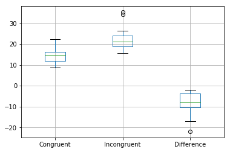

```python
f.boxplot()
```

可见，每对数据中Incongruent的时间都大于Congruent。  
Difference的离散程度最大，均值约为-8

(5) 现在，执行统计测试并报告你的结果。你的置信水平和关键统计值是多少？你是否成功拒绝零假设？对试验任务得出一个结论。结果是否与你的期望一致？

对$\mu_D$进行负向单尾检验：

```python
#mean
mu=f.mean()['Difference']
print(mu)
```

```
-7.96479166667
```

```python
#df
df=f.count()['Difference']-1
print(df)
```

```
23
```

```python
#SEM
SEM=f.sem()['Difference']
print(SEM)
```

```
0.993028634778
```

```python
#CI
margin_of_error=2.069*SEM
print('({},{})'.format(mu-margin_of_error,mu+margin_of_error))
```

```
(-10.019367912023053,-5.91021542131028)
```

```python
#mean difference
mean_diff=mu-0
print(mean_diff)
```

```
-7.96479166667
```

```python
#t statistic
t=mean_diff/SEM
print(t)
```

```
-8.02070694411
```

查表[2]得，t-critical value at α=0.05,df=23,单尾,为1.714  
t(23)=(-8.02),p<.05,one-tailed  
拒绝零假设  
confidence interval on the mean difference;  
95%CI=(-10.02,-5.91)  
结论：不一致文字条件会增加时间耗费，与期望一致。

(6)可选：你觉得导致所观察到的效应的原因是什么？你是否能想到会取得类似效应的替代或类似任务？进行一些调查研究将有助于你思考这两个问题！

效应可能原因：自动地处理语义会干扰读取颜色词语  
类似：don-pak-ski:一边猜拳一边报出错误手势的游戏

参考资料:  
[1][What assumptions are made when conducting a t-test?](https://www.investopedia.com/ask/answers/073115/what-assumptions-are-made-when-conducting-ttest.asp)  
[2][T-table](https://s3.amazonaws.com/udacity-hosted-downloads/t-table.jpg)  
[Markdown Cheatsheet](https://github.com/adam-p/markdown-here/wiki/Markdown-Cheatsheet#blockquotes)  
[A Primer on Using LaTeX in Jupyter Notebooks](http://data-blog.udacity.com/posts/2016/10/latex-primer/)  
[Udacity-P1-检验心理现象](https://classroom.udacity.com/nanodegrees/nd002/parts/0021345402)  
[minitab-检验的类型](https://support.minitab.com/zh-cn/minitab/18/help-and-how-to/statistics/basic-statistics/supporting-topics/tests-of-means/types-of-t-tests/)  
[Udacity forum-独立和相依样本区别](https://github.com/ShiChJ/DAND-Basic-Materials/blob/master/P1/%E7%8B%AC%E7%AB%8B%E5%92%8C%E7%9B%B8%E4%BE%9D%E6%A0%B7%E6%9C%AC%E5%8C%BA%E5%88%AB.pdf)  
麦金尼. 利用Python进行数据分析[M]. 机械工业出版社, 2014.  
[pandas.Series.quantile](http://pandas.pydata.org/pandas-docs/stable/generated/pandas.Series.quantile.html)